# JavaSDK 11のインストール

> オブジェクト指向プログラミングおよび演習1 第1回

# 開発環境のインストールを行います

講義で使用するJavaのバージョンは、JDK11を使用します。

最新版の12でない理由は、11がLTS版として長期サポート対応版だからです。

## 配布元よりダウンロード

配布元： [Java SE Development Kit 11- - Downloads](https://www.oracle.com/technetwork/java/javase/downloads/jdk11-downloads-5066655.html)

以下の画像に従い、ダウンロードして下さい。

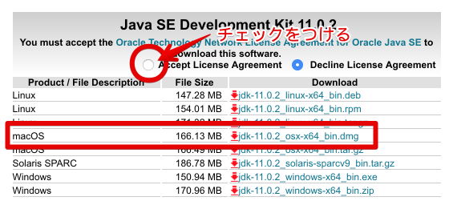

およそ167MByteあります。 皆さん同時にダウンロードすると、回線が混み合って遅くなる場合があります。ダウンロードが遅くても完了まで気長にお待ちください。 (あまりにも時間がかかりそうだったら、テキストエディタのAtomを先にダウンロード、インストールしてください。)

## インストール

1. ダウンロードした`jdk-11.0.2_osx-x64_bin.dmg`を開く
2. `JDK 11.0.2.pkg`を開く

[figure not shown]

3. 画面に従い、インストール
4. 以上

## インストールの確認

1. ターミナルを起動
   - [control] + [space] (El Capitan以降の場合、[⌘] + [space]) で Spotlight から terminal を起動
2. 以下のコマンドを入力してエンターキー

```bash
$ java –version
```

```
java version "11.0.2" 2019-01-15 LTS
Java(TM) SE Runtime Environment 18.9 (build 11.0.2+9-LTS)
Java HotSpot(TM) 64-Bit Server VM 18.9 (build 11.0.2+9-LTS, mixed mode)
```

上記のようなJavaのバージョン情報が表示されればインストール完了です。

もし以前にAndroidアプリの開発などをされた経験のある方は、ここで、“1.7”などの数値が出てきている場合があります。 前期の講義の大半はversion 1.7でも問題ありませんが、一部で紹介するJavaの新機能を使えない場合もありますのでご注意ください。

複数バージョンのJavaをインストールした場合、参考資料にある「複数バージョンのJavaをインストールした場合のNetBeans設定」を見て追加の環境設定を行ってください。

## 以上で設定は完了です。

まだテキストエディタを用意できていなければ、「02-Atomのインストールと設定」へお進みください。